# Covid-19 Progression Analysis

# Introduction

This updates a prior [post](https://www.elucidor.com/2020/03/19/coronavirus-analysis-are-we-italy/) analyzing the growth rate of Covid-19 infections and deaths by country.

The analysis is conducted as of 2020-03-24

The daily growth rate of cumulative confirmed cases and deaths are calculated as:

- $G_{confirmed}=growth~rate~confirmed=log(Confirmed_t / Confirmed_{t-1})$
- $G_{deaths}=growth~rate~deaths=log(Deaths_t / Deaths_{t-1})$

Using this formulation, the total growth after $d$ days is $total_{confirmed}=exp(d . G_{confirmed})$ and similarly for deaths. From this formula, we can determine that the number of days to double deaths is $d^{double}_{deaths} = log(2)/G_{deaths}$. The final plot shows the doubling day period for cumulative deaths.

The analysis uses a Gaussian Process to smooth the growth rates. 95% Credible Intervals for the mean growth rate are also shown.

# Summary of Results

All countries in the analysis except China and South Korea are on a disastrous trajectory. There is some good news from the Italian data which shows a slow but steady improvement in the growth rates of infections and deaths, suggesting the Italian lock down is having at least a partial effect

# Confirmed Cumulative Infection Growth Rate

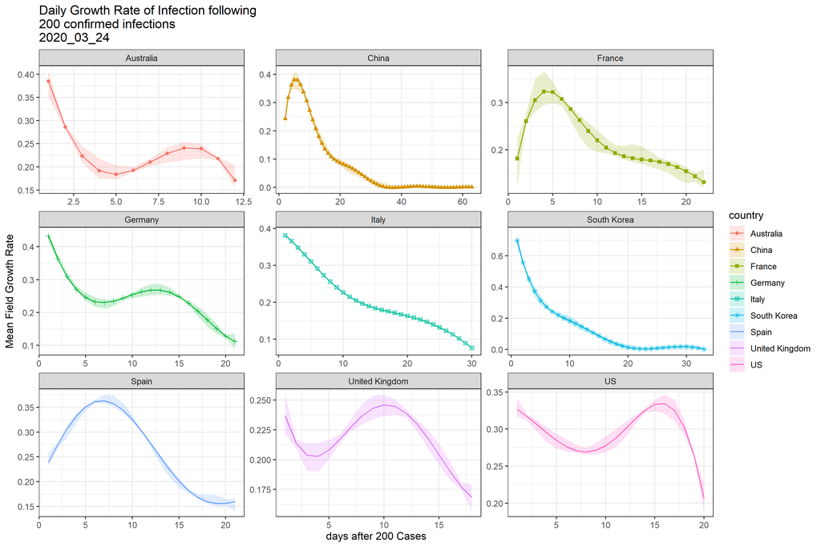

Confirmed Infection Growth Rate

# Confirmed Cumulative Death Growth Rate

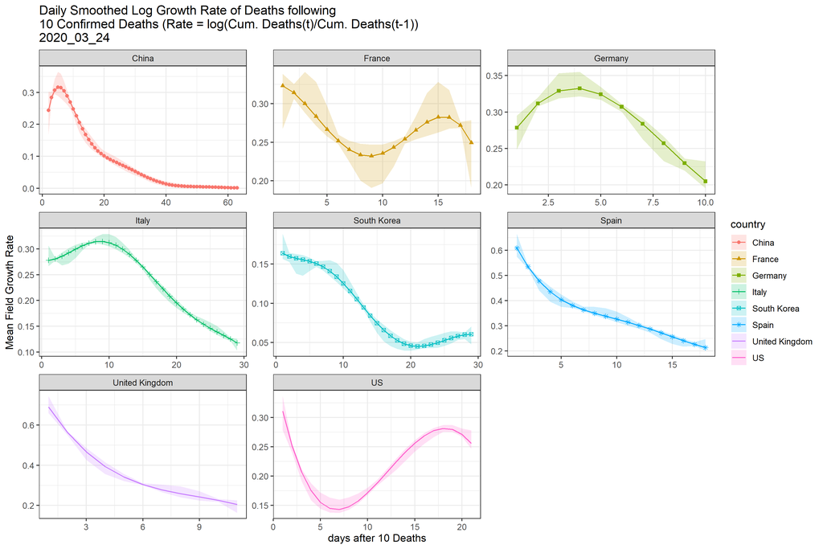

Confirmed Death Growth Rate

# Days to Double Cumulative Deaths

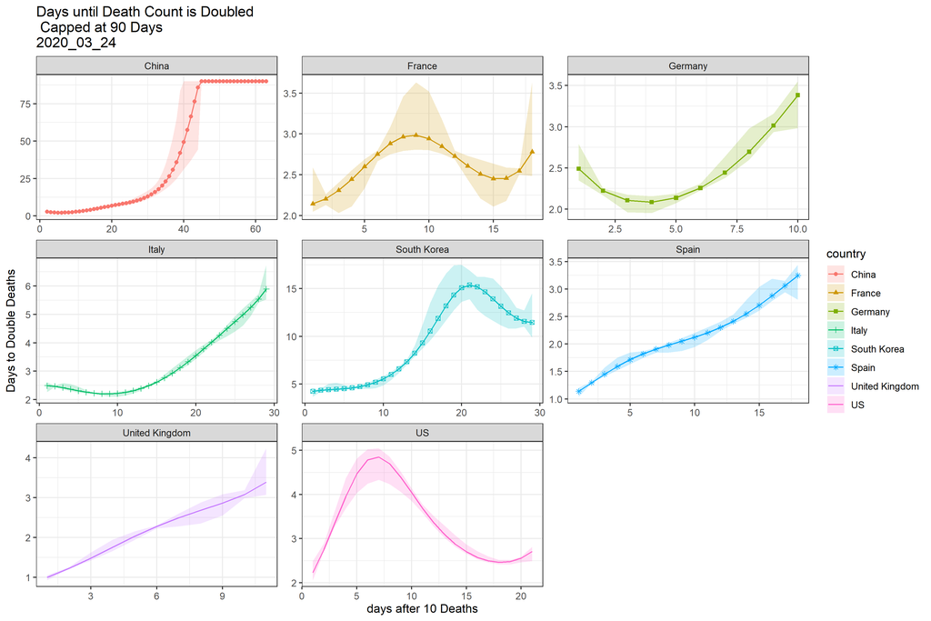

Confirmed Doubling Period for Deaths